# regression

VAZGEN TADEVOSYAN

April 26, 2019

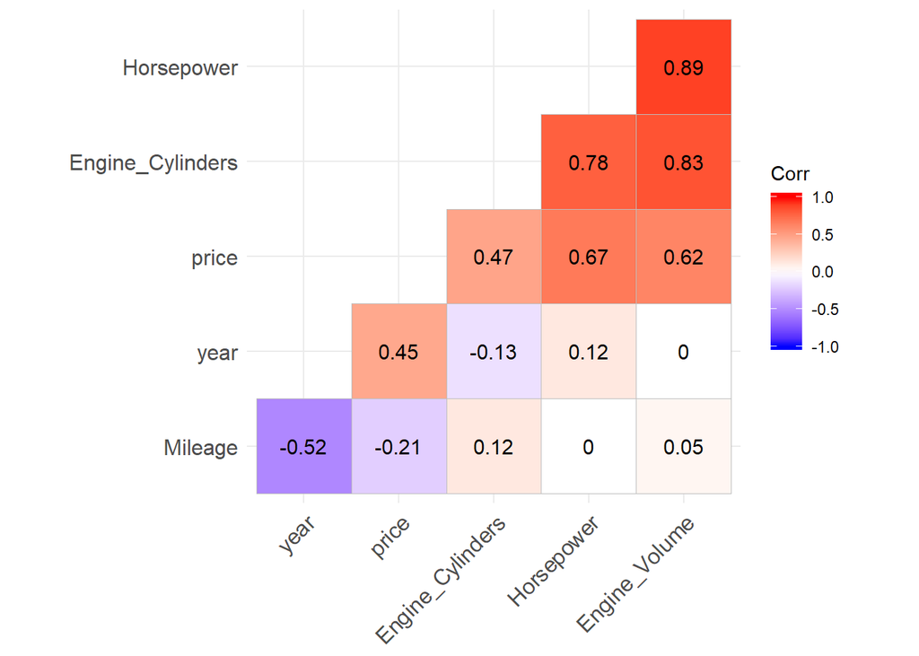

```r
library(ggplot2)
library(ggcorrplot)
library(dplyr)
Data<-read.csv("zz.csv")

only_num<-dplyr::select_if(Data, is.numeric)
ggcorrplot(cor(only_num), hc.order = TRUE, type = "lower",
   lab = TRUE)##first plot.
```

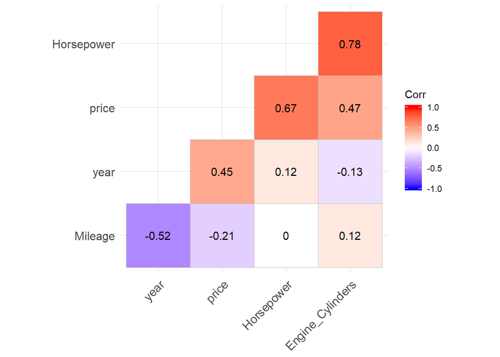

```r
only_num$Engine_Volume<-NULL
ggcorrplot(cor(only_num), hc.order = TRUE, type = "lower",
   lab = TRUE)##second plot.
```

**The plot states two most correlated numeric variables with “Price” are variables “Horsepower” and “Engine Volume”.The plot was also used to get all correlations to make assumption about multycolineary for further modeling.If we state threshold for correlation = 0.8, variables that are correlated with each other are “Horsepower”, “Engine Volume” and “Engine Cylinders”. we should exclude necessary ones to handle multicolineary problem , in further model we will include Horsepower because it has stronger correlation with Price than others.**

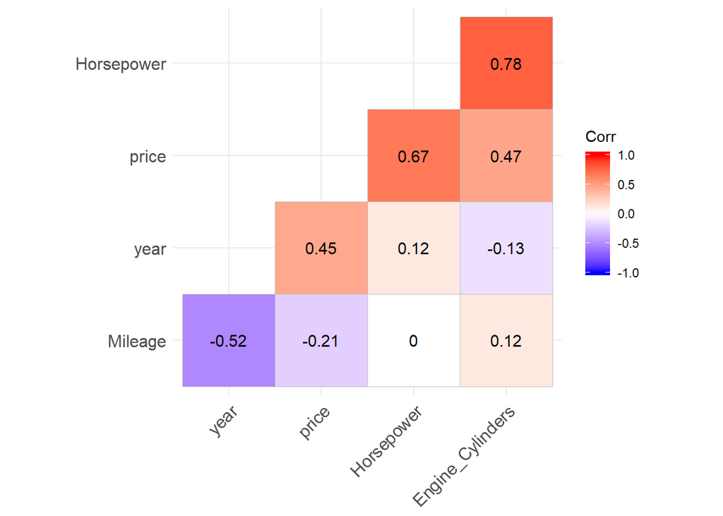

```r
only_num$Engine_Volume<-NULL
ggcorrplot(cor(only_num), hc.order = TRUE, type = "lower",
   lab = TRUE)
```

** After excluding Engine Valume variable we do not have pairs that have stronger correlation than our treshold.**

```r
library(nortest)
data<-read.csv("final2.csv")
ad.test(data$price)
```

```
##
##  Anderson-Darling normality test
##
## data:  data$price
## A = 3992.6, p-value < 2.2e-16
```

```r
shapiro.test(Data[Data$sold=="Yes","price"])
```

```
##
##  Shapiro-Wilk normality test
##
## data:  Data[Data$sold == "Yes", "price"]
## W = 0.72844, p-value < 2.2e-16
```